# Urban Institute Sparklyr Code and Guide

Graham MacDonald

Sparklyr is an R package built by RStudio to allow R users to take advantage of the dplyr library to analyze big data. This represents a huge step forward for programming in big data, as all other interfaces force social scientists to learn a completely new set of syntax and programming.

## Sparklyr Documentation

You can find the complete documentation for RStudio’s sparklyr package at https://spark.rstudio.com/.

## Setup

To get started, spin up a Spark cluster in R at the [Internal Form](https://shinyapps-stg.urban.org/emr-submission/). You will need to wait about 8 minutes for the cluster to start up, and then another five minutes when it’s up for it to install sparklyr in the background.

If you’d like to play around with the free data available on the site, just click on the Sparklyr tutorial in the bottom right pane and follow the code examples to read in the example data.

If you’d like to analyze data only available to those at Urban, such as the ZTRAX dataset, contact Graham MacDonald, Kyle Ueyama, or Manny Divina, who can provide you with an access key.

If you’d like to test on your local computer, keep in mind performance will be slower as you’ll be downloading files, and that it costs Urban $0.10/GB downloaded. So only view/read in data once you’ve subset and filtered, and preferably only very small subsets/filters, otherwise you’ll be waiting around a while.

Note that performance will be slower because a) you have many fewer processers than a full cluster, and b) the connection speed between Urban and Amazon is slower than the cluster, which is a connection between Amazon and Amazon.

When running locally, you will need to perform the following before using Sparklyr.

```r
install.packages('sparklyr')
spark_install(version = "2.2.0")
```

## Read Before You Start

**NOTE: ZTRAX data are available for use by Urban researchers, but may not be shared with anyone who is not an employee at the Urban Institute. ZTRAX data contain data such as owner name and address, and therefore any data user must submit an IRB packet for approval on a project-by-project basis.**

### Citation

Publications must provide the following citation on each page where results are published. In addition, any publications should notify Zillow at least 20 days in advance in order to ensure the citation is appropriate:

- Data provided by Zillow through the Zillow Transaction and Assessment Dataset (ZTRAX). More information on accessing the data can be found at http://www.zillow.com/ztrax. The results and opinions are those of the author(s) and do not reflect the position of Zillow Group

Publications must also publish online, or send to Zillow, any code used to manipulate, process, and/or analyze the data to produce published results.

Raw data must be aggregated, anonymized, and transformed so that it is in no way identifiable. Projects must conform to their IRB plan.

### Full Documentation

Full documentation and variable descriptions can be found at Urban’s internal [ZTRAX Documentation Folder](https://urbanorg.box.com/s/pl7v71q1aj5k10byhu59h2lw8b9rhqyp), a Box folder only available to Urban Institute employees.

### Data Available

All Zillow ZTRAX data are available in their original form, per the documentation above. Note that because we found a number of Errors in Zillow’s original CA file for Historic/BuildingAreasFixed_ZAsmt.parquet, not all data was able to be transferred for that state in that file. Available years vary by file, but in general, data are available up to 2016, and can begin at least 15 years before that.

## Reading in Data

To analyze the ZTRAX data, first load the sparklyr and dplyr libraries, set up the Spark configuration, and provide your access keys.

```r
library(sparklyr)
library(dplyr)
library(aws.s3)

config <- spark_config()
# When running on your local computer, add the following here:
# config[["sparklyr.defaultPackages"]] <- "org.apache.hadoop:hadoop-aws:2.7.1"

# When running on a cluster:
sc <- spark_connect(master = "yarn-client", config = config, version = '2.2.0')

# When running on your local computer:
# sc <- spark_connect(master = 'local', config = config, version = '2.2.0')

Sys.setenv(AWS_ACCESS_KEY_ID="[Your access key]")
Sys.setenv(AWS_SECRET_ACCESS_KEY="[Your secret access key]")
```

Now you can read in the data. There are one key consideration when reading in data in Parquet format - whether to read the data into memory or not (memory = TRUE or FALSE). Reading the data into memory means much faster computation on the data, but if your cluster size is not big enough, the operation can hang and you’ll end up waiting a long time for no results. Most of the time, it is safe to use memory = FALSE. However, if you know the size of your data and available memory in your cluster, memory = TRUE may make the most sense in some cases.

```r
dat <- spark_read_parquet(sc, "dat", "s3n://ui-zillow/parquet-data/Historic/Value_ZAsmt.parquet", memory = FALSE)
```

## Column Names and Data Types

Sparklyr reads in metadata about the dataset, but not the data itself, in memory = FALSE, which allows you to display some basic information, like column names and data types. In the newer versions of RStudio, you can view this in the Connections tab on the top right of your screen by clicking the blue arrow next to “dat”. But you can also do it from the console.

```r
colnames(dat)
```

```
##  [1] "RowID"                     "LandAssessedValue"
##  [3] "ImprovementAssessedValue"  "TotalAssessedValue"
##  [5] "AssessmentYear"            "LandMarketValue"
##  [7] "ImprovementMarketValue"    "TotalMarketValue"
##  [9] "MarketValueYear"           "LandAppraisalValue"
## [11] "ImprovementAppraisalValue" "TotalAppraisalValue"
## [13] "AppraisalValueYear"        "FIPS"
## [15] "BatchID"
```

```r
sdf_schema(dat)
```

```
## $RowID
## $RowID$name
## [1] "RowID"
##
## $RowID$type
## [1] "StringType"
##
##
## $LandAssessedValue
## $LandAssessedValue$name
## [1] "LandAssessedValue"
##
## $LandAssessedValue$type
## [1] "StringType"
##
##
## $ImprovementAssessedValue
## $ImprovementAssessedValue$name
## [1] "ImprovementAssessedValue"
##
## $ImprovementAssessedValue$type
## [1] "StringType"
##
##
## $TotalAssessedValue
## $TotalAssessedValue$name
## [1] "TotalAssessedValue"
##
## $TotalAssessedValue$type
## [1] "StringType"
##
##
## $AssessmentYear
## $AssessmentYear$name
## [1] "AssessmentYear"
##
## $AssessmentYear$type
## [1] "IntegerType"
##
##
```

[output cut: 63 more lines]

```
##
## $FIPS
## $FIPS$name
## [1] "FIPS"
##
## $FIPS$type
## [1] "StringType"
##
##
## $BatchID
## $BatchID$name
## [1] "BatchID"
##
## $BatchID$type
## [1] "IntegerType"
```

## Number of Rows

Getting the number of rows requires Spark to read the data. Because Parquet is a columnar storage format, this operation will be much faster if we select only one column, which requires Spark to only read in a small subset of the data file.

```r
dat1 <- dat %>%
          select(RowID)
count(dat1)
```

```
## # Source:   lazy query [?? x 1]
## # Database: spark_connection
##            n
##        <dbl>
## 1 1214739974
```

## Viewing the Dataset

You could view the dataset in full as you would in a normal R environment, but that would try to read the full dataset into memory on one computer, which is impossible in most big data use cases. Instead, if you’d like to view the dataset, you can subsample a small percentage (using the count function above will help you determine what that is) and display that sample. Again, first we select only the columns we need to significantly speed up data read time.

```r
dat1 <- dat %>%
            select(FIPS, TotalAssessedValue, AssessmentYear) %>%
            sdf_sample(fraction = 0.0000001, replacement = FALSE)
dat1
```

```
## # Source:   table<sparklyr_tmp_14c14370d238c> [?? x 3]
## # Database: spark_connection
##    FIPS  TotalAssessedValue AssessmentYear
##    <chr> <chr>                       <int>
##  1 06037 84288.0000                   2000
##  2 06057 36365.0000                   2011
##  3 06059 879900.0000                  2005
##  4 13051 28440.0000                   2015
##  5 37019 <NA>                         2013
##  6 12031 62340.0000                   2000
##  7 35001 70790.0000                   2008
##  8 06037 167554.0000                  2007
##  9 37051 8844.0000                    2008
## 10 06037 84718.0000                   2005
## # ... with more rows
```

Note that the operation processed immediately but if you type “dat1” and then press Enter, it takes a few seconds to process. Spark only executes commands when the following happens:

- you enter the name of the dataset into the console and type enter, or
- you end your dplyr statements with %>% collect()
- you execute a machine learning model

Until you do one of those three things, Spark merely stores your commands in order to optimize them under the hood until you actually need a result. So to view the data itself within the first line of the previous code chunk and store it, you might edit the command as follows.

```r
dat1 <- dat %>%
            select(FIPS, TotalAssessedValue, AssessmentYear) %>%
            sdf_sample(fraction = 0.0000001, replacement = FALSE) %>%
            collect()
dat1
```

```
## # A tibble: 128 x 3
##    FIPS  TotalAssessedValue AssessmentYear
##    <chr> <chr>                       <int>
##  1 06059 498121.0000                  2013
##  2 16085 50246.0000                   2013
##  3 37153 43811.0000                   2014
##  4 12069 85056.0000                   2002
##  5 06013 98000.0000                   2010
##  6 12103 311000.0000                  2007
##  7 12073 120021.0000                  2005
##  8 37063 194278.0000                  2004
##  9 06059 367095.0000                  2009
## 10 06037 950000.0000                  2007
## # ... with 118 more rows
```

“dat1” is now a “tibble”, or the tidyverse version of a dataframe, that is in memory in your local computer, or master node.

## Analyzing data

Now that you’ve gotten a good look at the properties of your dataset, you’re likely ready to analyze it. This is the true power of sparklyr: most of the dplyr functions are natively supported in this environment and parallelized under the hood. I won’t go over it here, but dplyr is very easy and straightforward, and you can learn the basics via one of the many nice [cheatsheets](https://www.rstudio.com/wp-content/uploads/2015/02/data-wrangling-cheatsheet.pdf).

Here’s an example of analyzing the mean assessed value of properties by state and year, in the process filtering NA values, creating a new variable, changing data type, subsetting, summarizing, and sorting.

```r
dat2 <- dat %>%
          select(FIPS, TotalAssessedValue, AssessmentYear) %>%
          filter(!is.na(TotalAssessedValue)) %>%
          mutate(State = substr(FIPS, 1, 2), AssessedValue = as.numeric(TotalAssessedValue)) %>%
          filter(AssessedValue > 0) %>%
          group_by(State, AssessmentYear) %>%
          summarise(value = mean(AssessedValue)) %>%
          filter(!is.na(State), !is.na(AssessmentYear)) %>%
          arrange(State, AssessmentYear) %>%
          collect()
dat2
```

```
## # A tibble: 776 x 3
## # Groups:   State [49]
##    State AssessmentYear value
##    <chr>          <int> <dbl>
##  1 01              1999  9208
##  2 01              2000 17148
##  3 01              2001 17547
##  4 01              2002 13090
##  5 01              2003 18274
##  6 01              2004 41273
##  7 01              2005 44226
##  8 01              2006 32479
##  9 01              2007 34031
## 10 01              2008 32049
## # ... with 766 more rows
```

## Plotting data

First, run an analysis like the one above to subset your data to a manageable size and collect() it to a local computer. Once you’ve done that, you can plot it using R’s standard ggplot2 package. For information on how to use this package, see the [Urban Institute R Graphics Guide](http://urbaninstitute.github.io/urban_R_theme/). One example of plotting the data analyzed above is included here for reference. Note that it could be substantially improved.

```r
source('https://raw.githubusercontent.com/UrbanInstitute/urban_R_theme/master/urban_theme_mac.R')
```

```
## Registering fonts with R
```

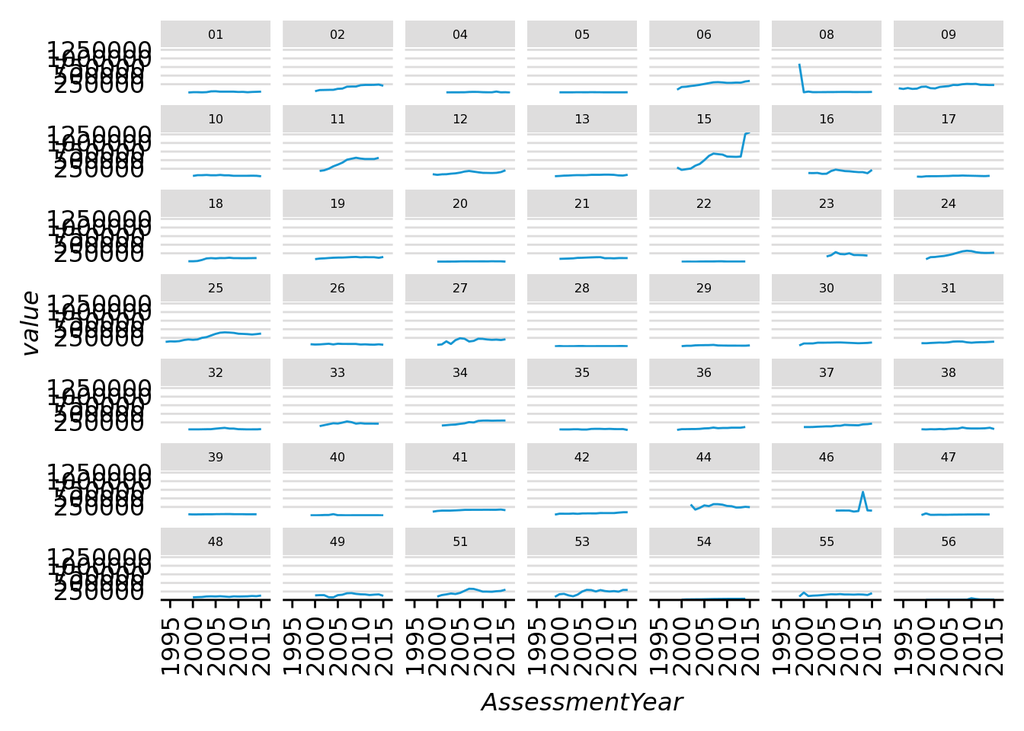

```r
state_assessed <- dat2 %>%
                        ggplot(aes(x=AssessmentYear, y=value)) +
                          geom_line() +
                          facet_wrap(~State) +
                          scale_y_continuous(expand = c(0, 0)) +
                          theme(axis.text.x = element_text(angle = 90),
                                strip.text = element_text(face = "plain", size = rel(0.5)))
state_assessed
```

## Writing data locally

Now that you’ve analyzed the data, perhaps you’d rather look at it in Excel than in RStudio, or you’d like to export the results to keep on your computer. To write data out, simply use standard R’s write function.

```r
write.csv(dat2, "Mean_Assessment_Year_State.csv")
```

In the bottom right pane of RStudio, under the “Files” tab, you should now have a new csv file. To download to your local computer, click the check box next to the file, click the “More” button at the top of the bottom right pane, and choose Export, then name the file and click Download.

## Run a linear regression

Say you want to run a linear regression on your data. Spark has a number of regression and machine learning libraries available - a complete list is available at [RStudio’s sparklyr website](https://spark.rstudio.com/mllib.html). In this case, we first convert a variable to numeric and then remove NA values, then we regress Total Assessed Value of a property on the year in which it is assessed. Because Spark is doing parallel computation, it is using a slightly different method to compute regressions than traditional statistical packages - for a more complete discussion, see [Spark’s MLLib documentation](https://spark.apache.org/docs/2.2.0/mllib-optimization.html#implementation-in-mllib).

```r
dat4 <- dat %>%
            select(TotalAssessedValue, AssessmentYear) %>%
            mutate(Total = as.numeric(TotalAssessedValue)) %>%
            filter(!is.na(Total), !is.na(AssessmentYear))
reg <- dat4 %>%
            ml_linear_regression(response = "Total", features = c("AssessmentYear"))
```

```
## * No rows dropped by 'na.omit' call
```

To view a summary of the regression output, use the traditional summary() syntax from R. Note that with a dataset with over one billion rows, the p value will always be (very) signficant, even if the R-squared value is quite low.

```r
summary(reg)
```

```
## Call: ml_linear_regression(., response = "Total", features = c("AssessmentYear"))
##
## Deviance Residuals: (approximate):
##      Min       1Q   Median       3Q      Max
##  -163556  -110503   -63458    27601 38547052
##
## Coefficients:
##                   Estimate  Std. Error t value  Pr(>|t|)
## (Intercept)    -8.4645e+06  9.8036e+03 -863.41 < 2.2e-16 ***
## AssessmentYear  4.2819e+03  4.8816e+00  877.15 < 2.2e-16 ***
## ---
## Signif. codes:  0 '***' 0.001 '**' 0.01 '*' 0.05 '.' 0.1 ' ' 1
##
## R-Squared: 0.0007024
## Root Mean Squared Error: 699100
```

## Analyzing Data that requires sorting

If you play around with Sparklyr enough you’ll notice a peculiar function missing - the median, and you may notice that things like sorts and rankings take a lot longer than variable creation and filters. This is because sorting in parallel involves a lot of data transfer and re-analysis between each of the processors working separately across multiple machines.

Still, Spark is much faster than an individual computer than doing these operations, but you have to be more patient - and the general rule is to select() and filter() as much as possible before performing these operations to maximize speed.

## Calculating a Median

To calculate the median, you must first rank your data (by group or overall) and select the data that comes closest to a rank of 0.5. Note that this will not get you the exact median to all decimal places, but in a large dataset, it will get you very, very close. The following is an example of such an implementation.

```r
dat5 <- dat %>%
            select(FIPS, TotalAssessedValue) %>%
            filter(!is.na(TotalAssessedValue), FIPS == "11001") %>%
            mutate(assess = as.numeric(TotalAssessedValue)) %>%
            group_by(FIPS) %>% mutate(rank = percent_rank(assess)) %>%
            filter(rank < 0.5001, rank > 0.4999) %>%
            summarise(median = mean(assess)) %>%
            collect()
dat5
```

```
## # A tibble: 1 x 2
##   FIPS  median
##   <chr>  <dbl>
## 1 11001 284168
```

## Sorting data

You will very likely need to sort data, and this is, luckily, supported by dplyr’s native arrange() function.

```r
dat6 <- dat %>%
            select(FIPS, TotalAssessedValue) %>%
            filter(FIPS == "11001") %>%
            mutate(assess = as.numeric(TotalAssessedValue)) %>%
            arrange(desc(assess)) %>%
            collect()
dat6
```

```
## # A tibble: 1,980,818 x 3
##    FIPS  TotalAssessedValue    assess
##    <chr> <chr>                  <dbl>
##  1 11001 201077010.0000     201077010
##  2 11001 200162700.0000     200162700
##  3 11001 194660570.0000     194660570
##  4 11001 194657570.0000     194657570
##  5 11001 189347600.0000     189347600
##  6 11001 189347600.0000     189347600
##  7 11001 188800000.0000     188800000
##  8 11001 177073100.0000     177073100
##  9 11001 172882470.0000     172882470
## 10 11001 160794000.0000     160794000
## # ... with 1,980,808 more rows
```

## Joining data

You will very likely want to join data from two datasets, and we provide an example of a join with another ZTRAX dataset.

```r
data_to_join <- spark_read_parquet(sc, "data_to_join", "s3n://ui-zillow/parquet-data/Historic/Building_ZAsmt.parquet", memory = FALSE)
data_summary <- data_to_join %>%
                              select(RowID, TotalBedrooms, FIPS) %>%
                              filter(FIPS == "11001") %>% group_by(RowID) %>%
                              summarise(bedrooms = sum(TotalBedrooms)) %>%
                              select(RowID, bedrooms) # Group by lot to join with lot data
data_value <- dat %>%
                  select(RowID, TotalAssessedValue, FIPS) %>%
                  filter(FIPS == "11001") %>%
                  mutate(assess = as.numeric(TotalAssessedValue)) %>%
                  select(RowID, assess)
data_joined <- data_summary %>%
                            inner_join(data_value)
data_view <- data_joined %>%
                          sdf_sample(fraction = 0.001, replacement = FALSE) %>%
                          collect()
data_view
```

```
## # A tibble: 1,992 x 3
##    RowID                                bedrooms assess
##    <chr>                                   <dbl>  <dbl>
##  1 0A2E2460-93D5-E511-80C1-3863BB43AC67     3.00 167280
##  2 52060166-2AD5-E511-80C1-3863BB43AC67     3.00 331630
##  3 5A3008E4-A1D5-E511-80C1-3863BB43AC67   NaN     99159
##  4 6FD58965-2AD5-E511-80C1-3863BB43AC67     2.00 512560
##  5 9A9BC6EB-C4D5-E511-80C1-3863BB43AC67     2.00 275980
##  6 A1D15B0B-48D5-E511-80C1-3863BB43AC67     3.00 308080
##  7 BC322D1A-52D5-E511-80C1-3863BB43AC67     4.00 282660
##  8 C6E75C1A-52D5-E511-80C1-3863BB43AC67     3.00 676030
##  9 D200121B-52D5-E511-80C1-3863BB43AC67     2.00 145720
## 10 DF52A65B-40D5-E511-80C1-3863BB43AC67     2.00 541360
## # ... with 1,982 more rows
```

## Appending a dataset to the end of another

You may have two large datasets that you want to combine one on top of the other. This is supported by an extension to Spark.

```r
dat7 <- spark_read_parquet(sc, "dat", "s3n://ui-zillow/parquet-data/Current/Value_ZAsmt.parquet", memory = FALSE)
combined <- sdf_bind_rows(dat7 %>% select(FIPS), dat %>% select(FIPS))
dat8 <- combined %>%
                  sdf_sample(fraction = 0.0000001, replacement = FALSE) %>%
                  collect()
dat8
```

```
## # A tibble: 40 x 1
##    FIPS
##    <chr>
##  1 04003
##  2 06065
##  3 12063
##  4 12105
##  5 13145
##  6 26065
##  7 27035
##  8 48109
##  9 51087
## 10 51810
## # ... with 30 more rows
```

## Extracting Big Data to CSV

You may want to take a CSV extract that’s too big to fit into memory, or takes too long to collect and process. Use the following function:

```r
write_out <- function(dataset, namein, bucket_path){
  bucket <- "ui-research"
  pathin <- paste("s3n://",bucket,"/",bucket_path,namein, sep="")
  pathin2 <- paste("s3://",bucket,"/",bucket_path,namein, sep="")
  spark_write_csv(dataset,pathin,header = FALSE)
  tempdf <- data.frame(matrix(vector(), 0, length(colnames(dataset)), dimnames=list(c(), colnames(dataset))), stringsAsFactors=F)
  write.csv(tempdf, 'temp.csv', row.names = FALSE)
  put_object('temp.csv', bucket = bucket, object = paste(bucket_path,namein,"/","0_header.csv", sep=""))
  Sys.setenv(inputpath=paste(pathin,"/",sep=""))
  Sys.setenv(outputpath=paste(pathin,".csv",sep=""))
  Sys.setenv(localpath=paste(pathin2,".csv",sep=""))
  print("Merging multiple files. DO NOT BE ALARMED.")
  system('hadoop fs -text ${inputpath}* | hadoop fs -put - ${outputpath}', ignore.stderr = TRUE, ignore.stdout = TRUE)
  system('aws s3 cp ${localpath} .')
  system('aws s3 rm ${localpath}')
  print("The file is ready to be downloaded from the file browser on the bottom right of your screen. Check the box next to the file, click 'More' and then click 'Export' to download the extract to your confidential folder on SAS1.")
}
```

And run it using the following code, for example:

```r
bucket_p <- "ec2-sandbox/my_extracts/"
write_out(data_joined, "DC_AssessedValue_Bedrooms", bucket_p)
```

```
## [1] "Merging multiple files. DO NOT BE ALARMED."
## [1] "The file is ready to be downloaded from the file browser on the bottom right of your screen. Check the box next to the file, click 'More' and then click 'Export' to download the extract to your confidential folder on SAS1."
```

## If you encounter errors

If you ever interrupt a job by pressing the Stop button at the top right of the console (on the bottom left of the screen), or you encounter an error where you know your code is correct, you may need to clear and restart your Spark session, and re-read your data.

```r
spark_disconnect(sc)
sc <- spark_connect(master = "yarn-client", config = config, version = '2.1.1')
dat <- spark_read_parquet(sc, "dat", "s3n://ui-zillow/parquet-data/Historic/Value_ZAsmt.parquet", memory = FALSE)
```

## ZTRAX table options

For a full list of ZTRAX table options, see The Urban Institute Big Data Portal Guide.